# Настройка DHCP для IPv4 и IPv6 в GNS3

Лабораторная работа №7

Гафоров Нурмухаммад

Российский университет дружбы народов, Москва, Россия

28 ноября 2025

# Цель работы

Получить практические навыки настройки механизмов **DHCP**, **DHCPv6 (Stateless/Stateful)** и автоматической конфигурации IPv6 (**SLAAC**, **RA**) в среде **GNS3** с использованием маршрутизатора **VyOS** и клиентских узлов.

# Ход выполнения

## Первичная топология и настройка IPv4 DHCP

В GNS3 создана базовая сеть, включающая маршрутизатор, коммутатор и хост **PC1-ngaforov**.

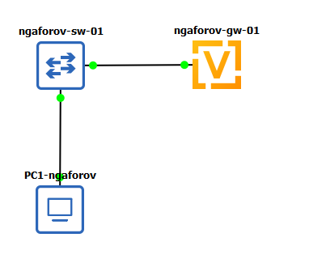

Топология IPv4

## Настройка DHCP для IPv4

- сеть: **10.0.0.0/24**
- диапазон: **10.0.0.2 — 10.0.0.253**
- шлюз: **10.0.0.1**
- DNS: **10.0.0.1**

[figure not shown]

DHCP IPv4

## Получение IPv4-адреса клиентом

Узел **PC1-ngaforov** получил адрес **10.0.0.2/24** через полный цикл DORA:  
**Discover → Offer → Request → Ack**.

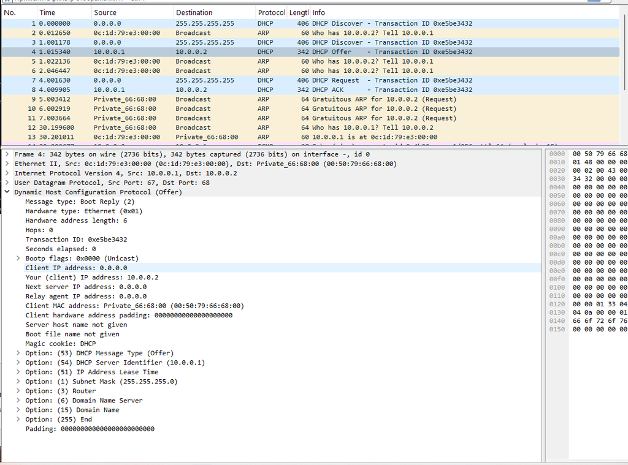

DORA в Wireshark

## Расширение топологии для IPv6

Добавлены коммутаторы **ngaforov-sw-02**, **ngaforov-sw-03** и клиент **PC2-ngaforov** (Kali Linux), поддерживающий DHCPv6.

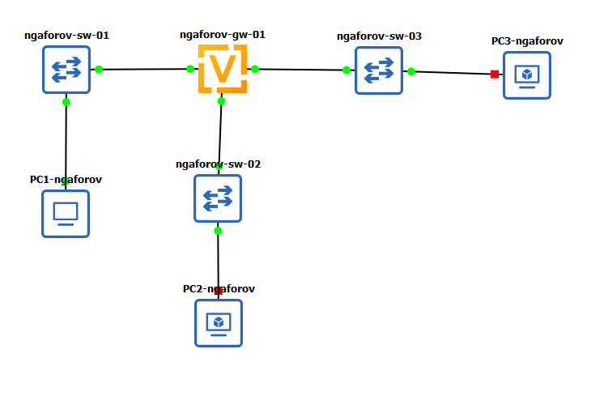

Расширенная топология

## Настройка IPv6-адресов на маршрутизаторе

Назначены адреса:

- eth1 → **2000::1/64**
- eth2 → **2001::1/64**

[figure not shown]

Интерфейсы IPv6

## Настройка SLAAC + DHCPv6 Stateless

- префикс: **2000::/64**
- флаг **other-config-flag**

DHCPv6 Stateless выдаёт только параметры: DNS, домен.

[figure not shown]

Stateless конфигурация

## Результат на клиенте PC2

PC2 получил IPv6-адрес по SLAAC и параметры DNS через DHCPv6 Stateless.

[figure not shown]

PC2 SLAAC

## DHCPv6 Stateless в Wireshark

Фиксация пакетов:

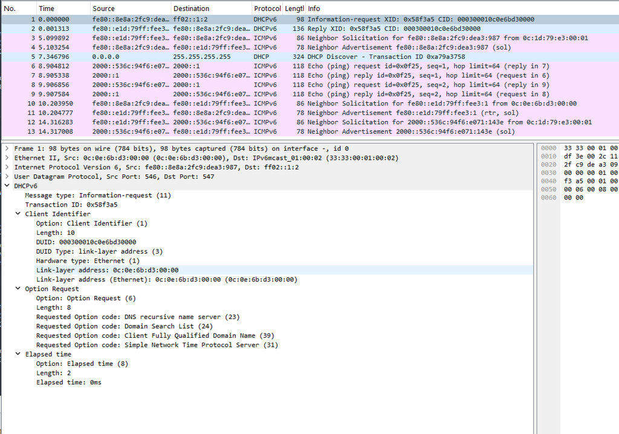

DHCPv6 Stateless Capture

## Настройка DHCPv6 Stateful

Создан DHCPv6-пул:

- диапазон: **2001::100 — 2001::199**
- DNS: **2001::1**
- domain-search: **ngaforov.net**

[figure not shown]

Stateful конфиг

## Получение IPv6-адреса PC3

Команда `dhclient -6 -v eth0` получила адрес из диапазона DHCPv6 Stateful — **2001::198/128**.

[figure not shown]

PC3 DHCPv6 Stateful

## Проверка маршрутизации и связности

Появился non-temporary IPv6-адрес, маршруты обновлены.  
Ping до **2001::1** успешен.

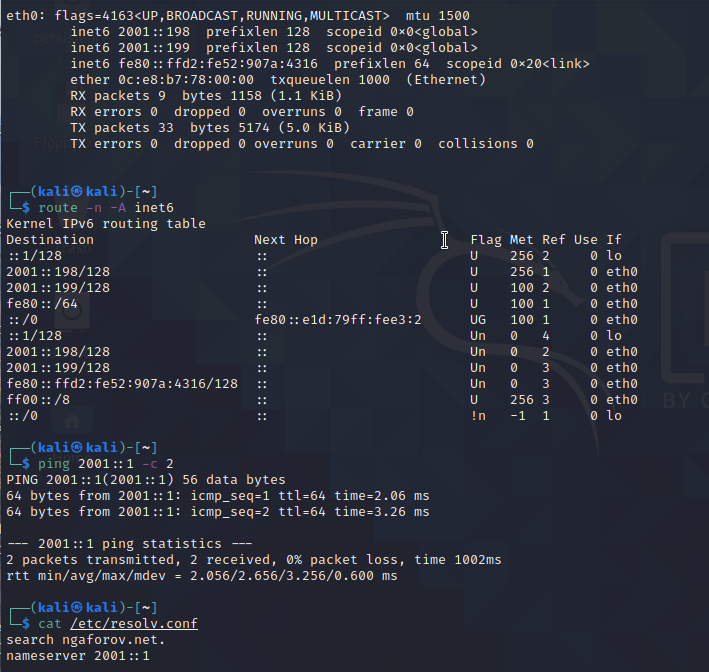

PC3 маршруты

## Таблица DHCPv6 Stateful

Маршрутизатор показывает активные аренды:

- **2001::198**
- **2001::199**

[figure not shown]

Таблица аренд

## DHCPv6 Stateful в Wireshark

Зафиксирован полный обмен:

- **Solicit**
- **Advertise**
- **Request**
- **Reply**

[figure not shown]

Stateful пакеты

# Выводы

В ходе работы:

- Выполнена настройка DHCP для IPv4 и IPv6.
- Исследованы два режима DHCPv6: **Stateless** и **Stateful**.
- Подтверждена корректная работа **SLAAC**, **RA**, **DHCPv6**.
- В Wireshark детально проанализированы циклы обмена:
  - **DORA** (IPv4)
  - **Information-Request / Reply** (Stateless)
  - **Solicit → Advertise → Request → Reply** (Stateful)

Работа позволила закрепить навыки построения IPv4/IPv6-сетей, настройки VyOS и анализа трафика.